# R Notebook

## BRIEF

This document is about exploring and extracting some insights from the Storm Data which is an official publication of National Oceanic and Atmospheric Administration. Across the USA starting from 1950 to 2011 meteorological events are observed with its results such as injuries, fatalities and damages on crops and on properties. We are going to investigate if event types are correlated with damage types.  
At first section We will download the data and clean some of it, transform the data, look at columns and group events to have ideas which events are more dangerous for human life and have strong impact on economy. We will compare top events that effects most. We will plot our data to understand better and see relations between events and damages. And we will examine by years and also by seasons of events. This data can be investigated by different points of view. But for more detailed analysis data has to be cleaned very carefully. Especially between 1950-1970 some stats are missing or deployed with personal measurements.

## DATA PROCESSING

We will download the data as bz2 zip file format.

```r
url <- "https://d396qusza40orc.cloudfront.net/repdata%2Fdata%2FStormData.csv.bz2"
download.file(url, destfile = "./data.zip")
```

Bzfiles can be read without decompositioning.

```r
data <- read.csv(bzfile("./data.zip"))
```

First we look at structure of our dataset.

```r
str(data)
```

```
'data.frame':   902297 obs. of  37 variables:
 $ STATE__   : num  1 1 1 1 1 1 1 1 1 1 ...
 $ BGN_DATE  : chr  "4/18/1950 0:00:00" "4/18/1950 0:00:00" "2/20/1951 0:00:00" "6/8/1951 0:00:00" ...
 $ BGN_TIME  : chr  "0130" "0145" "1600" "0900" ...
 $ TIME_ZONE : chr  "CST" "CST" "CST" "CST" ...
 $ COUNTY    : num  97 3 57 89 43 77 9 123 125 57 ...
 $ COUNTYNAME: chr  "MOBILE" "BALDWIN" "FAYETTE" "MADISON" ...
 $ STATE     : chr  "AL" "AL" "AL" "AL" ...
 $ EVTYPE    : chr  "TORNADO" "TORNADO" "TORNADO" "TORNADO" ...
 $ BGN_RANGE : num  0 0 0 0 0 0 0 0 0 0 ...
 $ BGN_AZI   : chr  "" "" "" "" ...
 $ BGN_LOCATI: chr  "" "" "" "" ...
 $ END_DATE  : chr  "" "" "" "" ...
 $ END_TIME  : chr  "" "" "" "" ...
 $ COUNTY_END: num  0 0 0 0 0 0 0 0 0 0 ...
```

[output cut: 23 more lines]

And let’s have a look at first rows of the data:

[output not shown]

And dimension of data:

```r
dim(data)
```

```
[1] 902297     37
```

So we have 37 columns and 902297 rows. As we understand from the first impression from the data we have day and time of starting and ending event, place (county), event type (EVTYPE), length and width, force of event (F), fatalities and injuries from the event, damage types, latitude and longitude knowledge. But we have NA values in data. So let’s have a look how many NAs we have:

```r
colSums(is.na(data))
```

```
   STATE__   BGN_DATE   BGN_TIME  TIME_ZONE     COUNTY COUNTYNAME      STATE     EVTYPE  BGN_RANGE
         0          0          0          0          0          0          0          0          0
   BGN_AZI BGN_LOCATI   END_DATE   END_TIME COUNTY_END COUNTYENDN  END_RANGE    END_AZI END_LOCATI
         0          0          0          0          0     902297          0          0          0
    LENGTH      WIDTH          F        MAG FATALITIES   INJURIES    PROPDMG PROPDMGEXP    CROPDMG
         0          0     843563          0          0          0          0          0          0
CROPDMGEXP        WFO STATEOFFIC  ZONENAMES   LATITUDE  LONGITUDE LATITUDE_E LONGITUDE_    REMARKS
         0          0          0          0         47          0         40          0          0
    REFNUM
         0
```

We have char columns and there are “” values which can’t be detected by is.na function. So let’s try to find empty chars:

```r
table(data$CROPDMGEXP)
```

```
            ?      0      2      B      k      K      m      M
618413      7     19      1      9     21 281832      1   1994
```

We see count of empty chars as 618413. When we use table function we can see empty chars in first item, another example:

```r
table(data$PROPDMGEXP)
```

```
            -      ?      +      0      1      2      3      4      5      6      7      8      B      h
465934      1      8      5    216     25     13      4      4     28      4      5      1     40      1
     H      K      m      M
     6 424665      7  11330
```

So let’s take a look only first item of what table’s retrieve in only character type columns:

```r
for(i in 1:length(names(data))){
  if (class(data[,i]) =="character"){
    print(names(data)[i])
    print(table(data[,i])[1])
  }
}
```

```
[1] "BGN_DATE"
1/1/1966 0:00:00
               2
[1] "BGN_TIME"
00:00:00 AM
       2383
[1] "TIME_ZONE"
ADT
  3
[1] "COUNTYNAME"

1589
[1] "STATE"
  AK
4391
[1] "EVTYPE"
   HIGH SURF ADVISORY
                    1
[1] "BGN_AZI"

547332
[1] "BGN_LOCATI"

287743
[1] "END_DATE"

243411
[1] "END_TIME"

238978
[1] "END_AZI"

724837
[1] "END_LOCATI"

499225
[1] "PROPDMGEXP"

465934
[1] "CROPDMGEXP"

618413
[1] "WFO"

142069
[1] "STATEOFFIC"

248769
[1] "ZONENAMES"

594029
[1] "REMARKS"

287433
```

So we have empty chars in most of char columns. And what is the ratio of empty chars on total rows in same column?

```r
for(i in 1:length(names(data))){
  if (class(data[,i]) =="character"){
    print(names(data)[i])
    print(table(data[,i])[1]/902297)
  }
}
```

```
[1] "BGN_DATE"
1/1/1966 0:00:00
    2.216565e-06
[1] "BGN_TIME"
00:00:00 AM
0.002641037
[1] "TIME_ZONE"
         ADT
3.324848e-06
[1] "COUNTYNAME"

0.001761061
[1] "STATE"
         AK
0.004866469
[1] "EVTYPE"
   HIGH SURF ADVISORY
         1.108283e-06
[1] "BGN_AZI"

0.6065985
[1] "BGN_LOCATI"

0.3189005
[1] "END_DATE"

0.2697682
[1] "END_TIME"

0.2648551
[1] "END_AZI"

0.8033242
[1] "END_LOCATI"

0.5532823
[1] "PROPDMGEXP"

0.5163865
[1] "CROPDMGEXP"

0.6853763
[1] "WFO"

0.1574526
[1] "STATEOFFIC"

0.2757063
[1] "ZONENAMES"

0.658352
[1] "REMARKS"

0.318557
```

Some character columns don’t have any empty item which are:BGN_DATE,BGN_TIME, TIME_ZONE, STATE, EVTYPE. But in some columns empty chars are more common than others like %80.33 of END_AZI are empty chars.

```r
data$BGN_DATE[1]
```

```
[1] "4/18/1950 0:00:00"
```

We already have a time column and in BGN_DATE column time ” 0:00:00” is unnecessary:

```r
data$BGN_DATE <- gsub(" 0:00:00","",as.character(data$BGN_DATE))
data$BGN_DATE <- as.Date(data$BGN_DATE, format = "%m/%d/%Y")
```

We have 3 columns about date and time, first one is BGN_DATE second one is BGN_TIME and the last one is TIME_ZONE. We can paste all the columns and create a POSIXct column for further analysis.

```r
data$date_time <- paste(data$BGN_DATE, data$BGN_TIME, data$TIME_ZONE)
```

Let’s see if have what we wanted

```r
data$date_time[1]
```

```
[1] "1950-04-18 0130 CST"
```

It looks good. Now let’s have a look other char columns:

```r
str(data)
```

```
'data.frame':   902297 obs. of  38 variables:
 $ STATE__   : num  1 1 1 1 1 1 1 1 1 1 ...
 $ BGN_DATE  : Date, format: "1950-04-18" "1950-04-18" "1951-02-20" ...
 $ BGN_TIME  : chr  "0130" "0145" "1600" "0900" ...
 $ TIME_ZONE : chr  "CST" "CST" "CST" "CST" ...
 $ COUNTY    : num  97 3 57 89 43 77 9 123 125 57 ...
 $ COUNTYNAME: chr  "MOBILE" "BALDWIN" "FAYETTE" "MADISON" ...
 $ STATE     : chr  "AL" "AL" "AL" "AL" ...
 $ EVTYPE    : chr  "TORNADO" "TORNADO" "TORNADO" "TORNADO" ...
 $ BGN_RANGE : num  0 0 0 0 0 0 0 0 0 0 ...
 $ BGN_AZI   : chr  "" "" "" "" ...
 $ BGN_LOCATI: chr  "" "" "" "" ...
 $ END_DATE  : chr  "" "" "" "" ...
 $ END_TIME  : chr  "" "" "" "" ...
 $ COUNTY_END: num  0 0 0 0 0 0 0 0 0 0 ...
```

[output cut: 24 more lines]

Let’s look at END_DATE.

```r
unique(sapply(data$END_DATE, nchar))
```

```
[1]  0 17 16 18
```

So we can assume we have 4 kind of values in EDN_DATE including empty chars.

```r
table(sapply(data$END_DATE, nchar))
```

```
     0     16     17     18
243411 176777 436199  45910
```

We have many empty chars on this column. Let’s have a look at EVTYPE column:

```r
sort(unique(data$EVTYPE))
```

```
  [1] "   HIGH SURF ADVISORY"          " COASTAL FLOOD"                 " FLASH FLOOD"
  [4] " LIGHTNING"                     " TSTM WIND"                     " TSTM WIND (G45)"
  [7] " WATERSPOUT"                    " WIND"                          "?"
 [10] "ABNORMAL WARMTH"                "ABNORMALLY DRY"                 "ABNORMALLY WET"
 [13] "ACCUMULATED SNOWFALL"           "AGRICULTURAL FREEZE"            "APACHE COUNTY"
 [16] "ASTRONOMICAL HIGH TIDE"         "ASTRONOMICAL LOW TIDE"          "AVALANCE"
 [19] "AVALANCHE"                      "BEACH EROSIN"                   "Beach Erosion"
 [22] "BEACH EROSION"                  "BEACH EROSION/COASTAL FLOOD"    "BEACH FLOOD"
 [25] "BELOW NORMAL PRECIPITATION"     "BITTER WIND CHILL"              "BITTER WIND CHILL TEMPERATURES"
 [28] "Black Ice"                      "BLACK ICE"                      "BLIZZARD"
 [31] "BLIZZARD AND EXTREME WIND CHIL" "BLIZZARD AND HEAVY SNOW"        "Blizzard Summary"
 [34] "BLIZZARD WEATHER"               "BLIZZARD/FREEZING RAIN"         "BLIZZARD/HEAVY SNOW"
 [37] "BLIZZARD/HIGH WIND"             "BLIZZARD/WINTER STORM"          "BLOW-OUT TIDE"
 [40] "BLOW-OUT TIDES"                 "BLOWING DUST"                   "blowing snow"
 [43] "Blowing Snow"                   "BLOWING SNOW"                   "BLOWING SNOW- EXTREME WIND CHI"
```

[output cut: 314 more lines]

There are typos on the EVTYPE column and misplaced empty spaces also. And There are some Summary knowledge which will be investigated afterwards. But let’s first we fix the upper lower cases:

```r
data$EVTYPE <- toupper(data$EVTYPE)
```

Let’s have a look at Wind kind of events:

```r
grep("^WIND", unique(data$EVTYPE), value = TRUE)
```

```
 [1] "WIND"                 "WIND CHILL"           "WIND CHILL/HIGH WIND" "WIND DAMAGE"
 [5] "WINDS"                "WIND STORM"           "WIND/HAIL"            "WIND ADVISORY"
 [9] "WIND AND WAVE"        "WIND GUSTS"
```

Also there is WND or ” WIND”:

```r
grep("^WND", unique(data$EVTYPE), value = TRUE)
```

```
[1] "WND"
```

```r
grep("^ WIND", unique(data$EVTYPE), value = TRUE)
```

```
[1] " WIND"
```

Let’s merge them into one type:

```r
data$EVTYPE[data$EVTYPE =="WND" | data$EVTYPE ==" WIND" | data$EVTYPE =="WINDS"] <- "WIND"
```

And there are empty spaces in front of the words.

```r
spaced_list <- list(grep("^ ", unique(data$EVTYPE), value = TRUE))
```

Let’s fix empty spaces with trimws:

```r
for (i in 1:length(spaced_list[[1]])){
  data$EVTYPE[data$EVTYPE== spaced_list[[1]][i]]<-  trimws(spaced_list[[1]][i])
}
```

Now what do we have?

```r
unique(data$EVTYPE)
```

```
  [1] "TORNADO"                        "TSTM WIND"                      "HAIL"
  [4] "FREEZING RAIN"                  "SNOW"                           "ICE STORM/FLASH FLOOD"
  [7] "SNOW/ICE"                       "WINTER STORM"                   "HURRICANE OPAL/HIGH WINDS"
 [10] "THUNDERSTORM WINDS"             "RECORD COLD"                    "HURRICANE ERIN"
 [13] "HURRICANE OPAL"                 "HEAVY RAIN"                     "LIGHTNING"
 [16] "THUNDERSTORM WIND"              "DENSE FOG"                      "RIP CURRENT"
 [19] "THUNDERSTORM WINS"              "FLASH FLOOD"                    "FLASH FLOODING"
 [22] "HIGH WINDS"                     "FUNNEL CLOUD"                   "TORNADO F0"
 [25] "THUNDERSTORM WINDS LIGHTNING"   "THUNDERSTORM WINDS/HAIL"        "HEAT"
 [28] "WIND"                           "LIGHTING"                       "HEAVY RAINS"
 [31] "LIGHTNING AND HEAVY RAIN"       "FUNNEL"                         "WALL CLOUD"
 [34] "FLOODING"                       "THUNDERSTORM WINDS HAIL"        "FLOOD"
 [37] "COLD"                           "HEAVY RAIN/LIGHTNING"           "FLASH FLOODING/THUNDERSTORM WI"
 [40] "WALL CLOUD/FUNNEL CLOUD"        "THUNDERSTORM"                   "WATERSPOUT"
 [43] "EXTREME COLD"                   "HAIL 1.75)"                     "LIGHTNING/HEAVY RAIN"
```

[output cut: 281 more lines]

There are some abbreviations. TSTM, CSTL, HVY, FLD. Let’s replace them with proper words: THUNDERSTROM, COASTAL, HEAVY and FLOOD respectively.

```r
data$EVTYPE <- gsub("TSTM*","THUNDERSTORM", data$EVTYPE)
data$EVTYPE <- gsub("CSTL*","COASTAL", data$EVTYPE)
data$EVTYPE <- gsub("HVY*","HEAVY", data$EVTYPE)
data$EVTYPE <- gsub("FLD*","FLOOD", data$EVTYPE)
```

```r
sort(unique(data$EVTYPE))
```

```
  [1] "?"                                    "ABNORMAL WARMTH"
  [3] "ABNORMALLY DRY"                       "ABNORMALLY WET"
  [5] "ACCUMULATED SNOWFALL"                 "AGRICULTURAL FREEZE"
  [7] "APACHE COUNTY"                        "ASTRONOMICAL HIGH TIDE"
  [9] "ASTRONOMICAL LOW TIDE"                "AVALANCE"
 [11] "AVALANCHE"                            "BEACH EROSIN"
 [13] "BEACH EROSION"                        "BEACH EROSION/COASTAL FLOODOOD"
 [15] "BEACH FLOODOOD"                       "BELOW NORMAL PRECIPITATION"
 [17] "BITTER WIND CHILL"                    "BITTER WIND CHILL TEMPERATURES"
 [19] "BLACK ICE"                            "BLIZZARD"
 [21] "BLIZZARD AND EXTREME WIND CHIL"       "BLIZZARD AND HEAVY SNOW"
 [23] "BLIZZARD SUMMARY"                     "BLIZZARD WEATHER"
 [25] "BLIZZARD/FREEZING RAIN"               "BLIZZARD/HEAVY SNOW"
 [27] "BLIZZARD/HIGH WIND"                   "BLIZZARD/WINTER STORM"
 [29] "BLOW-OUT TIDE"                        "BLOW-OUT TIDES"
```

[output cut: 424 more lines]

Let’s have a look some of the summaries as event type:

```r
data[data$EVTYPE=="SUMMARY SEPT. 25-26",]
```

|  | STATE__ | BGN_DATE | BGN_TIME | TIME_ZONE | COUNTY | COUNTYNAME | STATE | EVTYPE | BGN_RANGE | BGN_AZI | BGN_LOCATI | END_DATE | END_TIME | COUNTY_END | COUNTYENDN | END_RANGE | END_AZI | END_LOCATI | LENGTH | WIDTH | F | MAG | FATALITIES | INJURIES | PROPDMG | PROPDMGEXP | CROPDMG | CROPDMGEXP | WFO | … |
| --- | --- | --- | --- | --- | --- | --- | --- | --- | --- | --- | --- | --- | --- | --- | --- | --- | --- | --- | --- | --- | --- | --- | --- | --- | --- | --- | --- | --- | --- | --- |
| 271154 | 40 | 1996-09-25 | 05:25:00 PM | CST | 4 | OKZ004 - 007>008 - 010>013 | OK | SUMMARY SEPT. 25-26 | 0 |  |  | 9/26/1996 0:00:00 | 08:25:00 AM | 0 | NA | 0 |  |  | 0 | 0 | NA | 0 | 0 | 0 | 0 |  | 0 |  | OUN | … |

```r
data[data$EVTYPE=="SUMMARY OF MARCH 24-25",]
```

|  | STATE__ | BGN_DATE | BGN_TIME | TIME_ZONE | COUNTY | COUNTYNAME | STATE | EVTYPE | BGN_RANGE | BGN_AZI | BGN_LOCATI | END_DATE | END_TIME | COUNTY_END | COUNTYENDN | END_RANGE | END_AZI | END_LOCATI | LENGTH | WIDTH | F | MAG | FATALITIES | INJURIES | PROPDMG | PROPDMGEXP | CROPDMG | CROPDMGEXP | WFO | … |
| --- | --- | --- | --- | --- | --- | --- | --- | --- | --- | --- | --- | --- | --- | --- | --- | --- | --- | --- | --- | --- | --- | --- | --- | --- | --- | --- | --- | --- | --- | --- |
| 299357 | 40 | 1997-03-24 | 07:45:00 PM | CST | 6 | OKZ006>008 - 011>013 - 019>020 - 025>031 - 045>046 | OK | SUMMARY OF MARCH 24-25 | 0 |  |  | 3/24/1997 0:00:00 | 07:45:00 PM | 0 | NA | 0 |  |  | 0 | 0 | NA | 0 | 0 | 0 | 0 |  | 0 |  | OUN | … |

Let’s group these summaries and see if any injury or damage has recorded.

```r
summary(data[grepl("^SUMMARY", data$EVTYPE),])
```

```
    STATE__         BGN_DATE            BGN_TIME          TIME_ZONE             COUNTY
 Min.   :40.00   Min.   :1996-01-17   Length:75          Length:75          Min.   : 4.00
 1st Qu.:40.00   1st Qu.:1996-05-24   Class :character   Class :character   1st Qu.: 7.50
 Median :40.00   Median :1996-06-18   Mode  :character   Mode  :character   Median :17.00
 Mean   :41.71   Mean   :1996-07-10                                         Mean   :30.39
 3rd Qu.:40.00   3rd Qu.:1996-08-11                                         3rd Qu.:43.50
 Max.   :48.00   Max.   :1997-03-29                                         Max.   :89.00

  COUNTYNAME           STATE              EVTYPE            BGN_RANGE   BGN_AZI           BGN_LOCATI
 Length:75          Length:75          Length:75          Min.   :0   Length:75          Length:75
 Class :character   Class :character   Class :character   1st Qu.:0   Class :character   Class :character
 Mode  :character   Mode  :character   Mode  :character   Median :0   Mode  :character   Mode  :character
                                                          Mean   :0
                                                          3rd Qu.:0
                                                          Max.   :0

   END_DATE           END_TIME           COUNTY_END COUNTYENDN       END_RANGE   END_AZI
 Length:75          Length:75          Min.   :0    Mode:logical   Min.   :0   Length:75
 Class :character   Class :character   1st Qu.:0    NA's:75        1st Qu.:0   Class :character
 Mode  :character   Mode  :character   Median :0                   Median :0   Mode  :character
                                       Mean   :0                   Mean   :0
                                       3rd Qu.:0                   3rd Qu.:0
                                       Max.   :0                   Max.   :0

  END_LOCATI            LENGTH      WIDTH         F            MAG      FATALITIES    INJURIES    PROPDMG
 Length:75          Min.   :0   Min.   :0   Min.   : NA   Min.   :0   Min.   :0    Min.   :0   Min.   :0
 Class :character   1st Qu.:0   1st Qu.:0   1st Qu.: NA   1st Qu.:0   1st Qu.:0    1st Qu.:0   1st Qu.:0
 Mode  :character   Median :0   Median :0   Median : NA   Median :0   Median :0    Median :0   Median :0
                    Mean   :0   Mean   :0   Mean   :NaN   Mean   :0   Mean   :0    Mean   :0   Mean   :0
                    3rd Qu.:0   3rd Qu.:0   3rd Qu.: NA   3rd Qu.:0   3rd Qu.:0    3rd Qu.:0   3rd Qu.:0
                    Max.   :0   Max.   :0   Max.   : NA   Max.   :0   Max.   :0    Max.   :0   Max.   :0
                                            NA's   :75
  PROPDMGEXP           CROPDMG   CROPDMGEXP            WFO             STATEOFFIC         ZONENAMES
 Length:75          Min.   :0   Length:75          Length:75          Length:75          Length:75
 Class :character   1st Qu.:0   Class :character   Class :character   Class :character   Class :character
 Mode  :character   Median :0   Mode  :character   Mode  :character   Mode  :character   Mode  :character
                    Mean   :0
                    3rd Qu.:0
                    Max.   :0

    LATITUDE   LONGITUDE   LATITUDE_E   LONGITUDE_   REMARKS              REFNUM        date_time
 Min.   :0   Min.   :0   Min.   :0    Min.   :0    Length:75          Min.   :269437   Length:75
 1st Qu.:0   1st Qu.:0   1st Qu.:0    1st Qu.:0    Class :character   1st Qu.:270457   Class :character
 Median :0   Median :0   Median :0    Median :0    Mode  :character   Median :270931   Mode  :character
 Mean   :0   Mean   :0   Mean   :0    Mean   :0                       Mean   :273038
 3rd Qu.:0   3rd Qu.:0   3rd Qu.:0    3rd Qu.:0                       3rd Qu.:273196
 Max.   :0   Max.   :0   Max.   :0    Max.   :0                       Max.   :299496
```

So those rows doesn’t contain any injury or damage report. Those rows are kind of summary of some down rows and only contains the locations and it is not important for us. Because at down rows we can see details. SO let’s drop these rows from our data sets.

```r
data <- data[!grepl("^SUMMARY", data$EVTYPE),]
```

```r
dim(data)
```

```
[1] 902222     38
```

So we dropped 902297 - 902222 = 75 rows.

```r
str(data)
```

```
'data.frame':   902222 obs. of  38 variables:
 $ STATE__   : num  1 1 1 1 1 1 1 1 1 1 ...
 $ BGN_DATE  : Date, format: "1950-04-18" "1950-04-18" "1951-02-20" ...
 $ BGN_TIME  : chr  "0130" "0145" "1600" "0900" ...
 $ TIME_ZONE : chr  "CST" "CST" "CST" "CST" ...
 $ COUNTY    : num  97 3 57 89 43 77 9 123 125 57 ...
 $ COUNTYNAME: chr  "MOBILE" "BALDWIN" "FAYETTE" "MADISON" ...
 $ STATE     : chr  "AL" "AL" "AL" "AL" ...
 $ EVTYPE    : chr  "TORNADO" "TORNADO" "TORNADO" "TORNADO" ...
 $ BGN_RANGE : num  0 0 0 0 0 0 0 0 0 0 ...
 $ BGN_AZI   : chr  "" "" "" "" ...
 $ BGN_LOCATI: chr  "" "" "" "" ...
 $ END_DATE  : chr  "" "" "" "" ...
 $ END_TIME  : chr  "" "" "" "" ...
 $ COUNTY_END: num  0 0 0 0 0 0 0 0 0 0 ...
```

[output cut: 24 more lines]

Let’s take a look at F (Force of the event) column:

```r
table(data$F)
```

```
    0     1     2     3     4     5
24993 19475  9878  3179  1072   137
```

It seems this columns is being used for tornados especially.

```r
data$F[data$EVTYPE=="TORNADO"][1:10]
```

```
 [1] 3 2 2 2 2 2 2 1 3 3
```

Fatalities and injuries are human related damages, PROPDMG looks like a property numbers that effected from the event:

```r
unique(data$PROPDMG)[1:10]
```

```
 [1] 2.5e+04 2.5e+03 2.5e+06 2.5e+05 0.0e+00 3.0e+01 2.5e+02 2.5e+07 2.5e+08 5.0e+09
```

PROPDMGEXP seems like a categorical variable and it is a measurement of the property damage as dollars. K for Thousand dollars, M for Million dollars and B for Billion dollars.

```r
unique(data$PROPDMGEXP)
```

```
 [1] "K" "M" ""  "B" "m" "+" "0" "5" "6" "?" "4" "2" "3" "h" "7" "H" "-" "1" "8"
```

```r
data$PROPDMG[data$PROPDMGEXP=="h"]
```

```
[1] 2
```

So we should change the PROPDMG according to PROPDMGEXP. But there are numbers as characters and symbols +,- in PROPDMGEXP. Since those unknown categorizes are low numbered we will ignore them.

```r
dim(data)
```

```
[1] 902222     38
```

Now let’s have a look again to our PROPDMG column:

```r
sort(unique(data$PROPDMG), decreasing =T)[1:15]
```

```
 [1] 1.150e+11 3.130e+10 1.693e+10 1.126e+10 1.000e+10 7.350e+09 5.880e+09 5.420e+09 5.150e+09 5.000e+09
[11] 4.830e+09 4.000e+09 3.000e+09 2.800e+09 2.500e+09
```

CROPDMG column describes the agricultural damages of the event.

```r
unique(data$CROPDMG)
```

```
  [1]   0.00  10.00 500.00   1.00   4.00  50.00   5.00  15.00   0.50   0.40   0.05  21.00   7.00  17.00
 [15]  26.00  22.00   3.00   0.80  39.00  20.00 300.00   0.90  48.00   0.20   1.50   2.50   2.00 200.00
 [29]  25.00 130.00  37.00   9.00  45.00 185.00  35.00   2.20  12.00   0.30  90.00   0.15 100.00  66.00
 [43] 142.00   1.10   0.70 330.00 750.00   6.00  43.00  60.00 150.00   1.80 250.00  40.00   0.02   1.30
 [57]  30.00  70.00   0.01  80.00 350.00 400.00   8.00  75.00   3.50  63.00  18.00   0.28   0.10   1.70
 [71]   0.75   4.70  16.00 170.00 600.00 125.00   6.70   2.10 675.00   0.60 262.00 332.00 220.00  56.00
 [85]   0.03 353.00 177.00  36.00 373.00 430.00 160.00 123.00  13.00 140.00  38.00  52.00   0.24 320.00
 [99]   7.70   3.70   6.80   1.20 380.00   6.50   5.60  74.90  34.10  15.30  24.00   5.10  27.00  42.00
[113] 800.00 650.00 230.00  10.50  55.00   1.58   5.99   1.25   3.60   5.20   3.25   5.25   3.22 204.00
[127]   2.40 127.00   7.50  46.00  33.00 900.00 120.00 700.00   2.25  19.80   4.50 189.68   1.05  81.00
[141] 225.00  37.50   5.40   7.55   1.40  26.84   5.70 500.10 950.00  15.70  11.00  17.50 110.00   1.12
[155]  55.70   1.60  12.90  20.04  46.50  65.00   4.80   1.48  43.68 613.00  14.00  19.00   3.40 850.00
[169] 450.00 240.00   1.27   2.80  34.48  13.40  23.00  17.96  63.77   9.38  12.40   9.90   1.21  12.50
[183]   7.80 159.00 242.00 280.00  14.10   4.20   6.90   4.97 540.00 713.00   7.20   5.90  73.60   7.10
[197]  10.20   5.30  17.10 596.00  74.30 470.00 655.00 460.00 180.00   2.90 260.10 145.00   5.50   3.80
```

[output cut: 16 more lines]

And as in the property damage we have also a column named CROPDMGEXP.

```r
unique(data$CROPDMGEXP)
```

```
[1] ""  "M" "K" "m" "B" "?" "0" "k" "2"
```

OK. Now let’s look at other columns:

```r
str(data)
```

```
'data.frame':   902222 obs. of  40 variables:
 $ STATE__       : num  1 1 1 1 1 1 1 1 1 1 ...
 $ BGN_DATE      : Date, format: "1950-04-18" "1950-04-18" "1951-02-20" ...
 $ BGN_TIME      : chr  "0130" "0145" "1600" "0900" ...
 $ TIME_ZONE     : chr  "CST" "CST" "CST" "CST" ...
 $ COUNTY        : num  97 3 57 89 43 77 9 123 125 57 ...
 $ COUNTYNAME    : chr  "MOBILE" "BALDWIN" "FAYETTE" "MADISON" ...
 $ STATE         : chr  "AL" "AL" "AL" "AL" ...
 $ EVTYPE        : chr  "TORNADO" "TORNADO" "TORNADO" "TORNADO" ...
 $ BGN_RANGE     : num  0 0 0 0 0 0 0 0 0 0 ...
 $ BGN_AZI       : chr  "" "" "" "" ...
 $ BGN_LOCATI    : chr  "" "" "" "" ...
 $ END_DATE      : Date, format: NA NA NA ...
 $ END_TIME      : chr  "" "" "" "" ...
 $ COUNTY_END    : num  0 0 0 0 0 0 0 0 0 0 ...
```

[output cut: 26 more lines]

WFO, STATEOFFIC, ZONENAMES, LATITUDE, LONGITUDE, LATITUDE_E ,LONGITUDE_ are seems deployed with localization knowledge. And REFNUM is reference number for the events.

## RESULTS

We have explored our columns and have some knowledge about the data set. Now let’s think about it. In this dataset we would like to know which event type is more dangerous for humans or environment. That is going to be the first question.

```r
library(dplyr)
```

| EVTYPE | sum(PROPDMG) |
| --- | --- |
| ? | 5000.00 |
| ABNORMAL WARMTH | 0.00 |
| ABNORMALLY DRY | 0.00 |
| ABNORMALLY WET | 0.00 |
| ACCUMULATED SNOWFALL | 0.00 |
| AGRICULTURAL FREEZE | 0.00 |
| APACHE COUNTY | 5000.00 |
| ASTRONOMICAL HIGH TIDE | 9425000.00 |
| ASTRONOMICAL LOW TIDE | 320000.00 |
| AVALANCE | 0.00 |

[output cut: 801 more lines]

| EVTYPE | PROPDMG |
| --- | --- |
| FLOODOOD | 144657709807.00 |
| HURRICANE/TYPHOON | 69305840000.00 |
| TORNADO | 56937160778.70 |
| STORM SURGE | 43323536000.00 |
| FLOODASH FLOODOOD | 16140862067.10 |
| HAIL | 15732267047.70 |
| HURRICANE | 11868319010.00 |
| THUNDERSTORM WIND | 7976179779.00 |
| TROPICAL STORM | 7703890550.00 |
| WINTER STORM | 6688497251.00 |

[output cut: 801 more lines]

So FLOODOOD has the most damage impact over the properties. But as you could see there are so many similar event types like : FLOODASH FLOODOOD, RIVER FLOODOOD, FLOODASH FLOODOODING etc… So we can grepl those event types and sum of them but we should do the same to rest of the event types. Or we can try to categorize by guessing. What kind of events could have been done? Floods, Rains, Winds, Temperature related events, Snowing, Tornados, Erosion, etc…

| EVTYPE | PROPDMG |
| --- | --- |
| BITTER WIND CHILL | 0.00 |
| BITTER WIND CHILL TEMPERATURES | 0.00 |
| BLIZZARD AND EXTREME WIND CHIL | 0.00 |
| BLIZZARD/HIGH WIND | 0.00 |
| BLOWING SNOW- EXTREME WIND CHI | 0.00 |
| BLOWING SNOW & EXTREME WIND CH | 0.00 |
| BLOWING SNOW/EXTREME WIND CHIL | 0.00 |
| COLD WIND CHILL TEMPERATURES | 0.00 |
| COLD/WIND CHILL | 1990000.00 |
| COLD/WINDS | 0.00 |

[output cut: 199 more lines]

We can sum the property damages of the winds for sure. But how are we going to manage when two different types are combined like : RAIN/WIND, HIGH WINDS/SNOW, HEAVY SNOW AND STRONG WINDS ? So in this analysis we are going to consider unique events and won’t categorize the data. Let’s look at fatalities in events:

| EVTYPE | FATALITIES |
| --- | --- |
| TORNADO | 5633 |
| EXCESSIVE HEAT | 1903 |
| FLOODASH FLOODOOD | 978 |
| HEAT | 937 |
| LIGHTNING | 816 |
| THUNDERSTORM WIND | 637 |
| FLOODOOD | 470 |
| RIP CURRENT | 368 |
| HIGH WIND | 248 |
| AVALANCHE | 224 |

[output cut: 801 more lines]

TORNADO is in the top of the list with a big gap to other events in the list. And let’s look at the INJURIES:

| EVTYPE | INJURIES |
| --- | --- |
| TORNADO | 91346 |
| THUNDERSTORM WIND | 8445 |
| FLOODOOD | 6789 |
| EXCESSIVE HEAT | 6525 |
| LIGHTNING | 5230 |
| HEAT | 2100 |
| ICE STORM | 1975 |
| FLOODASH FLOODOOD | 1777 |
| HAIL | 1361 |
| WINTER STORM | 1321 |

[output cut: 801 more lines]

As expected tornados are the biggest threat for the human life.

And lastly let’s look at CROPDMG.

| EVTYPE | CROPDMG |
| --- | --- |
| DROUGHT | 13972566000 |
| FLOODOOD | 5661968450 |
| RIVER FLOODOOD | 5029459000 |
| ICE STORM | 5022113500 |
| HAIL | 3025954473 |
| HURRICANE | 2741910000 |
| HURRICANE/TYPHOON | 2607872800 |
| FLOODASH FLOODOOD | 1421317100 |
| EXTREME COLD | 1312973000 |
| FROST/FREEZE | 1094186000 |

[output cut: 801 more lines]

For agriculture DROUGHT is the biggest threat.

## PLOTTING SOME DATA

```r
library(ggplot2)
```

| EVTYPE | FATALITIES |
| --- | --- |
| TORNADO | 5633 |
| EXCESSIVE HEAT | 1903 |
| FLOODASH FLOODOOD | 978 |
| HEAT | 937 |
| LIGHTNING | 816 |
| THUNDERSTORM WIND | 637 |
| FLOODOOD | 470 |
| RIP CURRENT | 368 |
| HIGH WIND | 248 |
| AVALANCHE | 224 |

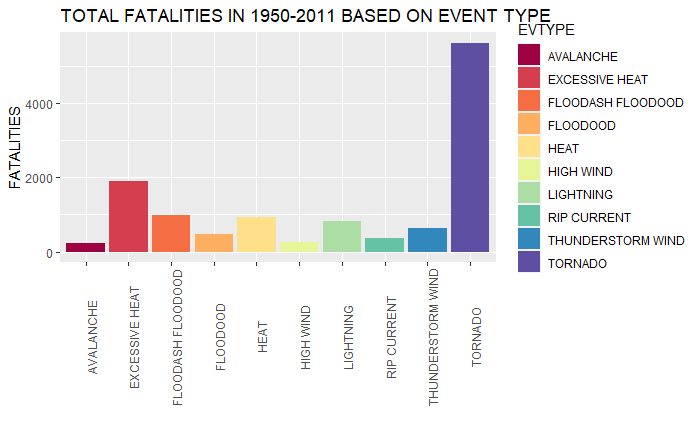

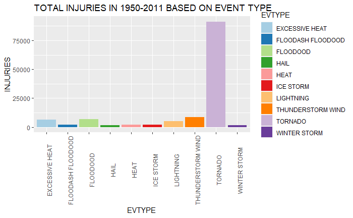

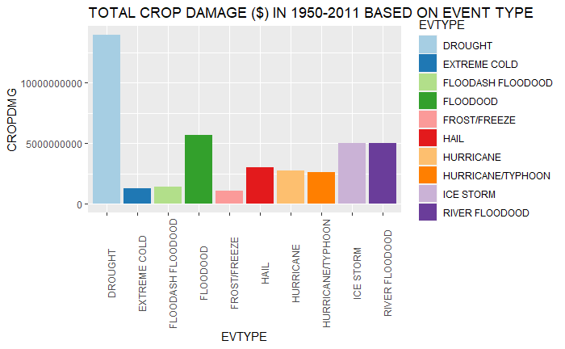

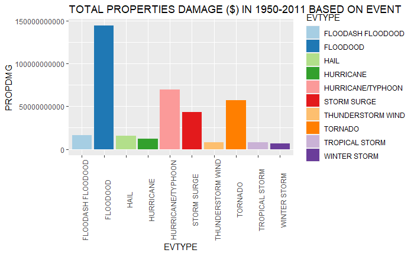

It seems Floodood has the biggest impact on property damages. We plotted the data we have already discussed and it is obvious that tornados are the biggest danger for the human life but for agriculture drought is the biggest threat as we can see. Now let’s investigate these events from different perspectives. Take a look at events from years:

|  | STATE__ | BGN_DATE | BGN_TIME | TIME_ZONE | COUNTY | COUNTYNAME | STATE | EVTYPE | BGN_RANGE | BGN_AZI | BGN_LOCATI | END_DATE | END_TIME | COUNTY_END | COUNTYENDN | END_RANGE | END_AZI | END_LOCATI | LENGTH | WIDTH | F | MAG | FATALITIES | INJURIES | PROPDMG | PROPDMGEXP | CROPDMG | CROPDMGEXP | WFO | … |
| --- | --- | --- | --- | --- | --- | --- | --- | --- | --- | --- | --- | --- | --- | --- | --- | --- | --- | --- | --- | --- | --- | --- | --- | --- | --- | --- | --- | --- | --- | --- |
| 1 | 1 | 1950-04-18 | 0130 | CST | 97 | MOBILE | AL | TORNADO | 0 |  |  |  |  | 0 | NA | 0 |  |  | 14.0 | 100 | 3 | 0 | 0 | 15 | 25000 | K | 0 |  |  | … |
| 2 | 1 | 1950-04-18 | 0145 | CST | 3 | BALDWIN | AL | TORNADO | 0 |  |  |  |  | 0 | NA | 0 |  |  | 2.0 | 150 | 2 | 0 | 0 | 0 | 2500 | K | 0 |  |  | … |
| 3 | 1 | 1951-02-20 | 1600 | CST | 57 | FAYETTE | AL | TORNADO | 0 |  |  |  |  | 0 | NA | 0 |  |  | 0.1 | 123 | 2 | 0 | 0 | 2 | 25000 | K | 0 |  |  | … |
| 4 | 1 | 1951-06-08 | 0900 | CST | 89 | MADISON | AL | TORNADO | 0 |  |  |  |  | 0 | NA | 0 |  |  | 0.0 | 100 | 2 | 0 | 0 | 2 | 2500 | K | 0 |  |  | … |
| 5 | 1 | 1951-11-15 | 1500 | CST | 43 | CULLMAN | AL | TORNADO | 0 |  |  |  |  | 0 | NA | 0 |  |  | 0.0 | 150 | 2 | 0 | 0 | 2 | 2500 | K | 0 |  |  | … |
| 6 | 1 | 1951-11-15 | 2000 | CST | 77 | LAUDERDALE | AL | TORNADO | 0 |  |  |  |  | 0 | NA | 0 |  |  | 1.5 | 177 | 2 | 0 | 0 | 6 | 2500 | K | 0 |  |  | … |
| 7 | 1 | 1951-11-16 | 0100 | CST | 9 | BLOUNT | AL | TORNADO | 0 |  |  |  |  | 0 | NA | 0 |  |  | 1.5 | 33 | 2 | 0 | 0 | 1 | 2500 | K | 0 |  |  | … |
| 8 | 1 | 1952-01-22 | 0900 | CST | 123 | TALLAPOOSA | AL | TORNADO | 0 |  |  |  |  | 0 | NA | 0 |  |  | 0.0 | 33 | 1 | 0 | 0 | 0 | 2500 | K | 0 |  |  | … |
| 9 | 1 | 1952-02-13 | 2000 | CST | 125 | TUSCALOOSA | AL | TORNADO | 0 |  |  |  |  | 0 | NA | 0 |  |  | 3.3 | 100 | 3 | 0 | 1 | 14 | 25000 | K | 0 |  |  | … |
| 10 | 1 | 1952-02-13 | 2000 | CST | 57 | FAYETTE | AL | TORNADO | 0 |  |  |  |  | 0 | NA | 0 |  |  | 2.3 | 100 | 3 | 0 | 0 | 0 | 25000 | K | 0 |  |  | … |

[output cut: 990 more lines]

Grouping the data based on crop damage, injuries and fatalities on years:

```r
library(lattice)
year_groups <- data %>% group_by(YEAR) %>% summarise(CROPDAMAGE = sum(CROPDMG), INJURIES = sum(INJURIES), FATALITIES = sum(FATALITIES))
```

| YEAR | CROPDAMAGE | INJURIES | FATALITIES |
| --- | --- | --- | --- |
| 1995 | 2941124460 | 4480 | 1491 |
| 2011 | 666742000 | 7792 | 1002 |
| 1999 | 3532284100 | 5148 | 908 |
| 1998 | 4507685350 | 11177 | 687 |
| 1997 | 1228079400 | 3800 | 601 |
| 2006 | 3534238700 | 3368 | 599 |
| 1996 | 1888530840 | 2717 | 542 |
| 1953 | 0 | 5131 | 519 |
| 2002 | 1410368140 | 3155 | 498 |
| 2008 | 2209793000 | 2703 | 488 |

[output cut: 52 more lines]

| YEAR | CROPDAMAGE | INJURIES | FATALITIES |
| --- | --- | --- | --- |
| 1998 | 4507685350 | 11177 | 687 |
| 2011 | 666742000 | 7792 | 1002 |
| 1974 | 0 | 6824 | 366 |
| 1965 | 0 | 5197 | 301 |
| 1999 | 3532284100 | 5148 | 908 |
| 1953 | 0 | 5131 | 519 |
| 1995 | 2941124460 | 4480 | 1491 |
| 1994 | 5806735341 | 4161 | 344 |
| 1997 | 1228079400 | 3800 | 601 |
| 2006 | 3534238700 | 3368 | 599 |

[output cut: 52 more lines]

| YEAR | CROPDAMAGE | INJURIES | FATALITIES |
| --- | --- | --- | --- |
| 1994 | 5806735341 | 4161 | 344 |
| 1993 | 5603603650 | 2149 | 298 |
| 1998 | 4507685350 | 11177 | 687 |
| 2005 | 4035202300 | 1834 | 469 |
| 2006 | 3534238700 | 3368 | 599 |
| 1999 | 3532284100 | 5148 | 908 |
| 2000 | 3329170600 | 2803 | 477 |
| 1995 | 2941124460 | 4480 | 1491 |
| 2008 | 2209793000 | 2703 | 488 |
| 1996 | 1888530840 | 2717 | 542 |

[output cut: 52 more lines]

Injuries most numbers are observed in 1998,2011 and 1974. Fatalities highest numbers are observed in 1995, 2011, 1999. So let’s compare these two variable in 1974,1995,1998,1999 and in 2011 (both have high numbers in 2011)

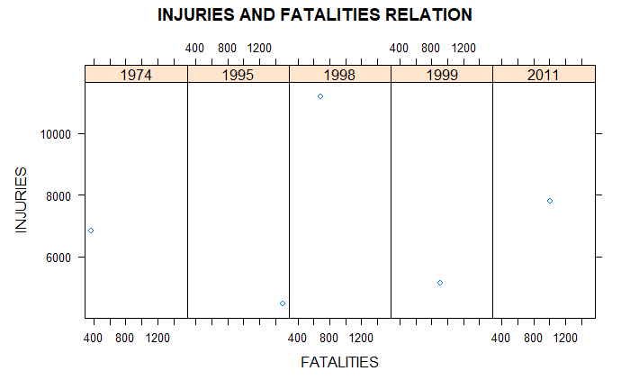

We could assume fatalities and injuries can be related but this doesn’t seem to be so true. Only 2011 both variables are high. For ex in 1974 injuries are 6824 but fatalities are 366.

Let’s do a similar comparison for crop damage and injuries:

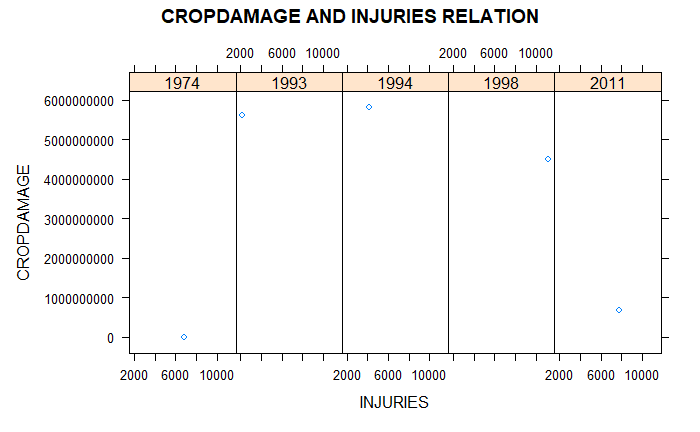

Let’s take a look at some event types damages:

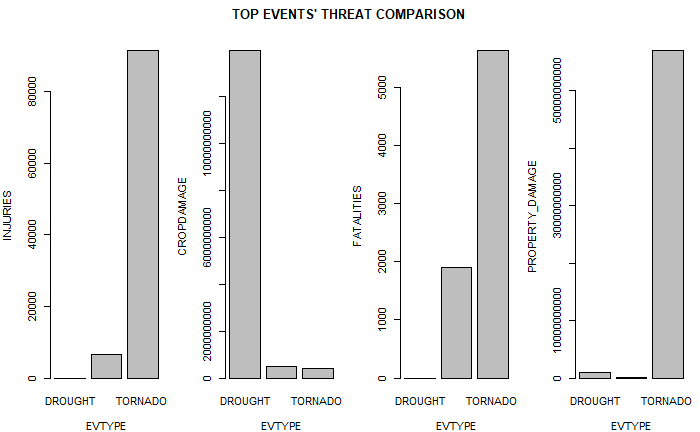

[output not shown]

And we will group the event damages by months.

|  | STATE__ | BGN_DATE | BGN_TIME | TIME_ZONE | COUNTY | COUNTYNAME | STATE | EVTYPE | BGN_RANGE | BGN_AZI | BGN_LOCATI | END_DATE | END_TIME | COUNTY_END | COUNTYENDN | END_RANGE | END_AZI | END_LOCATI | LENGTH | WIDTH | F | MAG | FATALITIES | INJURIES | PROPDMG | PROPDMGEXP | CROPDMG | CROPDMGEXP | WFO | … |
| --- | --- | --- | --- | --- | --- | --- | --- | --- | --- | --- | --- | --- | --- | --- | --- | --- | --- | --- | --- | --- | --- | --- | --- | --- | --- | --- | --- | --- | --- | --- |
| 1 | 1 | 1950-04-18 | 0130 | CST | 97 | MOBILE | AL | TORNADO | 0 |  |  |  |  | 0 | NA | 0 |  |  | 14.0 | 100 | 3 | 0 | 0 | 15 | 25000 | K | 0 |  |  | … |
| 2 | 1 | 1950-04-18 | 0145 | CST | 3 | BALDWIN | AL | TORNADO | 0 |  |  |  |  | 0 | NA | 0 |  |  | 2.0 | 150 | 2 | 0 | 0 | 0 | 2500 | K | 0 |  |  | … |
| 3 | 1 | 1951-02-20 | 1600 | CST | 57 | FAYETTE | AL | TORNADO | 0 |  |  |  |  | 0 | NA | 0 |  |  | 0.1 | 123 | 2 | 0 | 0 | 2 | 25000 | K | 0 |  |  | … |
| 4 | 1 | 1951-06-08 | 0900 | CST | 89 | MADISON | AL | TORNADO | 0 |  |  |  |  | 0 | NA | 0 |  |  | 0.0 | 100 | 2 | 0 | 0 | 2 | 2500 | K | 0 |  |  | … |
| 5 | 1 | 1951-11-15 | 1500 | CST | 43 | CULLMAN | AL | TORNADO | 0 |  |  |  |  | 0 | NA | 0 |  |  | 0.0 | 150 | 2 | 0 | 0 | 2 | 2500 | K | 0 |  |  | … |
| 6 | 1 | 1951-11-15 | 2000 | CST | 77 | LAUDERDALE | AL | TORNADO | 0 |  |  |  |  | 0 | NA | 0 |  |  | 1.5 | 177 | 2 | 0 | 0 | 6 | 2500 | K | 0 |  |  | … |

Let’s have a look at our new grouped data:

| MONTH | CROPDAMAGE | INJURIES | FATALITIES | PROPERTY_DAMAGE |
| --- | --- | --- | --- | --- |
| 01 | 2356695300 | 5412 | 895 | 121952761736 |
| 02 | 5665742500 | 9305 | 872 | 4418071672 |
| 03 | 1238148910 | 11676 | 1232 | 19070418116 |
| 04 | 1180305908 | 31426 | 2199 | 28975133879 |
| 05 | 2028351460 | 20267 | 1833 | 33883495062 |
| 06 | 6087114350 | 14809 | 1476 | 22714802667 |
| 07 | 5175046323 | 12267 | 2900 | 12141103681 |
| 08 | 12838077180 | 9598 | 1440 | 98138779008 |
| 09 | 6182992670 | 4255 | 762 | 48339006347 |
| 10 | 2333119430 | 9825 | 406 | 25485355019 |

[output cut: 2 more lines]

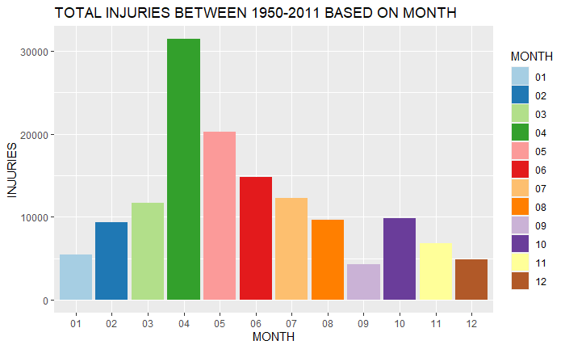

```r
month_injury <- ggplot(monthly_events, aes(MONTH,INJURIES, fill=MONTH))
month_injury + geom_col() + scale_fill_brewer(palette="Paired") + ggtitle("TOTAL INJURIES BETWEEN 1950-2011 BASED ON MONTH")
```

And fatalities by months:

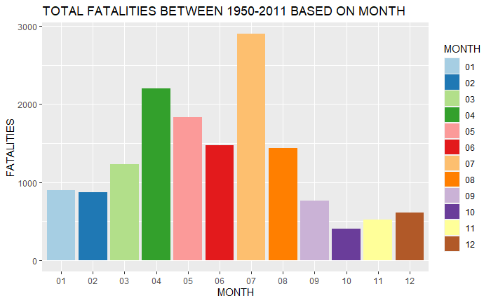

```r
month_fatality <- ggplot(monthly_events, aes(MONTH,FATALITIES, fill=MONTH))
month_fatality + geom_col() + scale_fill_brewer(palette="Paired") + ggtitle("TOTAL FATALITIES BETWEEN 1950-2011 BASED ON MONTH")
```

Property damages by months:

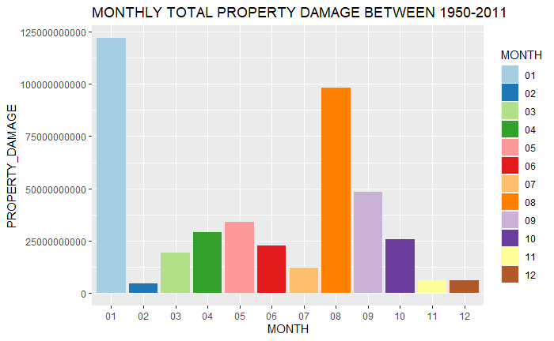

```r
month_prop <- ggplot(monthly_events, aes(MONTH,PROPERTY_DAMAGE, fill=MONTH))
month_prop + geom_col() + scale_fill_brewer(palette="Paired") + ggtitle("MONTHLY TOTAL PROPERTY DAMAGE BETWEEN 1950-2011")
```

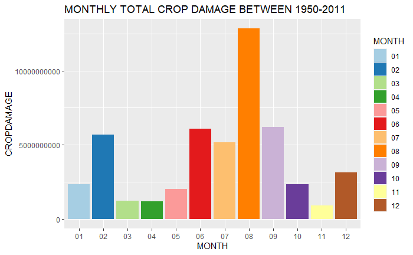

```r
month_crop <- ggplot(monthly_events, aes(MONTH,CROPDAMAGE, fill=MONTH))
month_crop + geom_col() + scale_fill_brewer(palette="Paired") + ggtitle("MONTHLY TOTAL CROP DAMAGE BETWEEN 1950-2011")
```

We now know tornados are the biggest danger for human life and drought is the biggest threat for the agriculture. And now we have learnt crop damage mostly taken at 8th month of the years. So can we assume droughts are being happening at 8 th months or droughts can be more damaging at 8th months? Let’s investigate this event type:

```r
drought <- data %>% group_by(EVTYPE) %>% subset(EVTYPE=="DROUGHT") %>% summarise(MONTH = MONTH, CROP_DAMAGE = sum(CROPDMG))
```

[output not shown]

[output cut: 2 more lines]

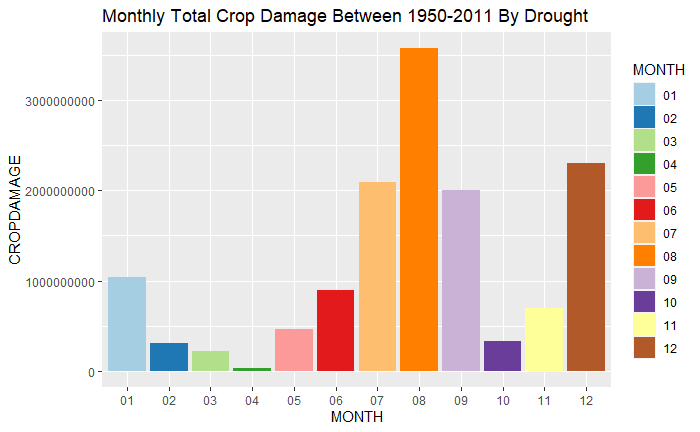

```r
drought_crop <- ggplot(drought, aes(MONTH,CROPDAMAGE, fill=MONTH))
drought_crop + geom_col() + scale_fill_brewer(palette="Paired") + ggtitle("Monthly Total Crop Damage Between 1950-2011 By Drought" )
```

We seem to be right about our guess. Droughts are dangerous at 8th months. We should investigate tornados also, tornados are the most dangerous event for human life. Let’s look which months tornados has caused fatalities:

```r
tornado <- data %>% group_by(EVTYPE) %>% subset(EVTYPE=="TORNADO") %>% group_by(MONTH) %>% summarise(FATALITIES = sum(FATALITIES))
```

| MONTH | FATALITIES |
| --- | --- |
| 01 | 137 |
| 02 | 436 |
| 03 | 662 |
| 04 | 1793 |
| 05 | 1253 |
| 06 | 565 |
| 07 | 67 |
| 08 | 121 |
| 09 | 95 |
| 10 | 99 |

[output cut: 2 more lines]

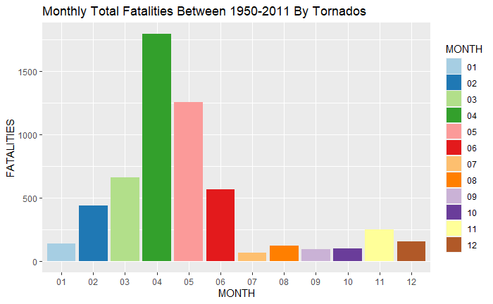

```r
tornado_fatality <- ggplot(tornado, aes(MONTH,FATALITIES, fill=MONTH))
tornado_fatality + geom_col() + scale_fill_brewer(palette="Paired") + ggtitle("Monthly Total Fatalities Between 1950-2011 By Tornados" )
```

From the chart we can assume at 4th and 5th months tornados are more fatal.